# Weight Lifting Exercise manner predicition

Basma Nasser

Friday, May 22, 2015

Using devices such as Jawbone Up, Nike FuelBand, and Fitbit it is now possible to collect a large amount of data about personal activity relatively inexpensively. These type of devices are part of the quantified self movement - a group of enthusiasts who take measurements about themselves regularly to improve their health, to find patterns in their behavior, or because they are tech geeks. One thing that people regularly do is quantify how much of a particular activity they do, but they rarely quantify how well they do it. In this project, your goal will be to use data from accelerometers on the belt, forearm, arm, and dumbell of 6 participants. They were asked to perform barbell lifts correctly and incorrectly in 5 different ways. More information is available from the website here: http://groupware.les.inf.puc-rio.br/har (see the section on the Weight Lifting Exercise Dataset).

## Objective

The goal of this project is to predict the manner in which 6 participants did the exercise. This is the “classe” variable in the training set.

### Data Preprocessing

Read data training and testing data set then clean data with variables that predict the movement as below.

```r
library(caret)
training_set <- read.csv("pml-training.csv", na.strings = c("NA", ""))
test_set <- read.csv("pml-testing.csv", na.strings = c("NA", ""))
```

2- remove variables which have near Zero variance which indicates that they do not contribute to the model.

3- remove NA columns from data sets,to avoid low accuracy in the model.

```r
trainRemove <- grepl("^X|user_name|cvtd_timestamp", names(training_set))
training_set <- training_set[, -trainRemove]

#zero variance
near_zero_var <- nearZeroVar(training_set)
training_set <- training_set[, -near_zero_var]

training_set <-training_set[,colSums(is.na(training_set)) == 0]
```

```r
#Set seed to reproduce the results
set.seed(8483)

#partition training data set
dp <- createDataPartition(y = training_set$classe, p = 0.2, list = FALSE)

sub_training <- training_set[dp, ]

sub_test <- training_set[-dp, ]  # test set for cross validation
```

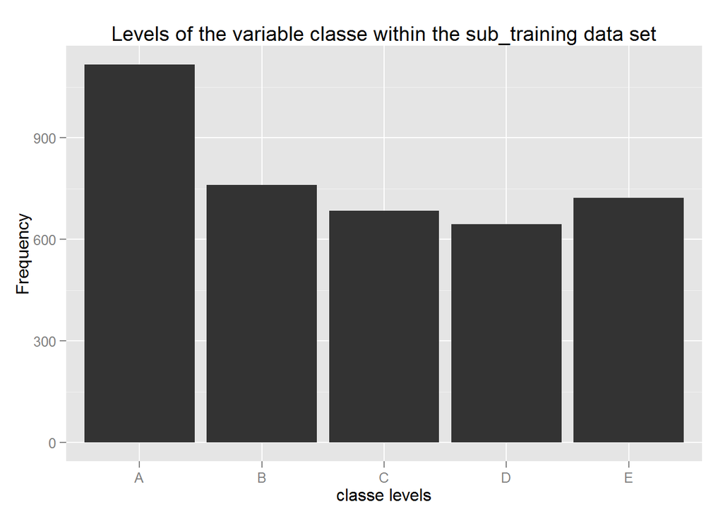

```r
library(ggplot2)

qplot(sub_training$classe, main="Levels of the variable classe within the sub_training data set", xlab="classe levels", ylab="Frequency")
```

## Model creation

1- Create model from new sub training dataset using rpart single tree.

```r
##Fit the model using the single tree method

modelFit <- train(classe ~ ., data = sub_training, method = "rpart")
```

calculate model accuracy

```r
results <- modelFit$results
round(max(results$Accuracy), 4) * 100
```

```
## [1] 68.92
```

2- Create model from new sub training dataset using random forests.

```r
##Fit the model using the Random Forest method

modelFit <- train(classe ~ ., data = sub_training, method = "rf")
##Print the model details.
print(modelFit$finalModel)
```

```
##
## Call:
##  randomForest(x = x, y = y, mtry = param$mtry)
##                Type of random forest: classification
##                      Number of trees: 500
## No. of variables tried at each split: 40
##
##         OOB estimate of  error rate: 0.92%
## Confusion matrix:
##      A   B   C   D   E  class.error
## A 1115   1   0   0   0 0.0008960573
## B    6 746   8   0   0 0.0184210526
## C    0   9 673   3   0 0.0175182482
## D    0   0   3 640   1 0.0062111801
## E    0   0   0   5 717 0.0069252078
```

Variable importance according to the model

```r
varImp(modelFit)
```

```
## rf variable importance
##
##   only 20 most important variables shown (out of 79)
##
##                                Overall
## raw_timestamp_part_1           100.000
## roll_belt                       50.459
## num_window                      41.313
## pitch_forearm                   33.651
## magnet_dumbbell_z               24.716
## magnet_dumbbell_y               19.500
## pitch_belt                      15.595
## yaw_belt                        15.163
## cvtd_timestamp28/11/2011 14:15  12.966
## cvtd_timestamp30/11/2011 17:12  12.280
## cvtd_timestamp02/12/2011 13:33  11.213
## magnet_dumbbell_x                8.699
## accel_belt_z                     8.526
## roll_forearm                     8.515
## cvtd_timestamp02/12/2011 14:58   7.615
## accel_dumbbell_y                 7.544
## roll_dumbbell                    7.258
## magnet_belt_y                    6.862
## accel_dumbbell_z                 6.248
## cvtd_timestamp05/12/2011 11:24   5.963
```

calculate model accuracy

```r
results <- modelFit$results
round(max(results$Accuracy), 4) * 100
```

```
## [1] 98.79
```

random forest model provides us with a model that has a much higher accuracy: 98.79 %

## Cross Validation

Use modelFit to predict new values within the sub_test dataset that we created for cross-validation

```r
predicted <- predict(modelFit,sub_test)
table(predicted, sub_test$classe)
```

```
##
## predicted    A    B    C    D    E
##         A 4461   16    0    0    0
##         B    3 3014   43    0    0
##         C    0    6 2677    4    0
##         D    0    1   17 2568   22
##         E    0    0    0    0 2863
```

As expected the predictions are not correct in all cases.

## Expected out of sample error

We can calculate the expected out of sample error based on the sub_test dataset that we created for cross-validation.

```r
confusionMatrix(predicted, sub_test$classe)
```

```
## Confusion Matrix and Statistics
##
##           Reference
## Prediction    A    B    C    D    E
##          A 4461   16    0    0    0
##          B    3 3014   43    0    0
##          C    0    6 2677    4    0
##          D    0    1   17 2568   22
##          E    0    0    0    0 2863
##
## Overall Statistics
##
##                Accuracy : 0.9929
##                  95% CI : (0.9914, 0.9941)
##     No Information Rate : 0.2844
##     P-Value [Acc > NIR] : < 2.2e-16
##
##                   Kappa : 0.991
##  Mcnemar's Test P-Value : NA
##
## Statistics by Class:
##
##                      Class: A Class: B Class: C Class: D Class: E
## Sensitivity            0.9993   0.9924   0.9781   0.9984   0.9924
## Specificity            0.9986   0.9964   0.9992   0.9970   1.0000
## Pos Pred Value         0.9964   0.9850   0.9963   0.9847   1.0000
## Neg Pred Value         0.9997   0.9982   0.9954   0.9997   0.9983
## Prevalence             0.2844   0.1935   0.1744   0.1639   0.1838
## Detection Rate         0.2842   0.1920   0.1706   0.1636   0.1824
## Detection Prevalence   0.2853   0.1950   0.1712   0.1662   0.1824
## Balanced Accuracy      0.9990   0.9944   0.9887   0.9977   0.9962
```

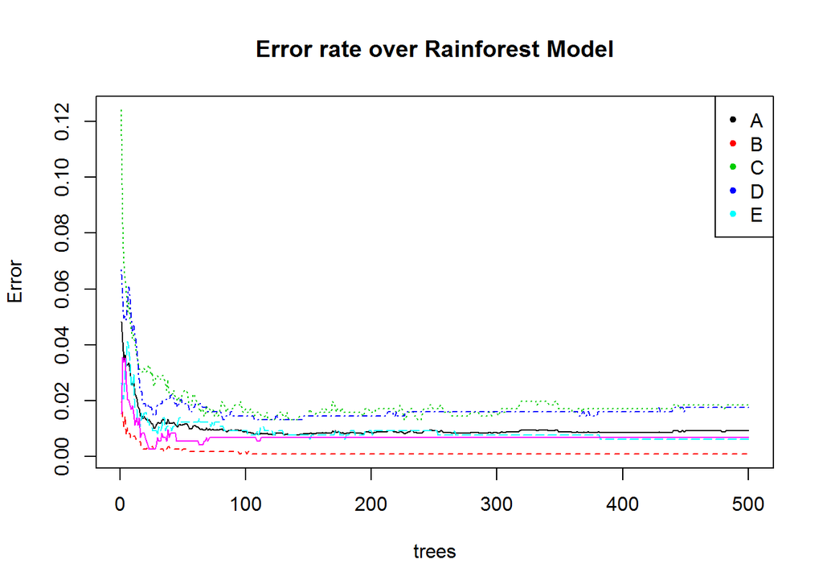

```r
plot(modelFit$finalModel, main="Error rate over Rainforest Model")
legend("topright", legend=unique(sub_test$classe), col=unique(as.numeric(sub_test$classe)), pch=20)
```

## Submission

Apply prediction model to predict 20 different test cases.

```r
#remove NA columns from original test set
test_set <-test_set[,colSums(is.na(test_set)) == 0]

#predict new values within the original test set
final_predicted <- predict(modelFit,test_set)

pml_write_files = function(x){
        n = length(x)
        for(i in 1:n){
                filename = paste0("problem_id_",i,".txt")
                write.table(x[i],file=filename,quote=FALSE,row.names=FALSE,col.names=FALSE)
        }
}

pml_write_files(final_predicted)
```